# Online Learning and Regret Minimization

73-423 Forecasting for Economics and Business

## Outline

- Decision Theory Review
- Regret Minimization
- The Online Learning Setting
- Discrete Case: Prediction with Expert Advice
  - Realizable Case
  - Nonrealizable Case
  - Application: The Mind Reading Machine
- Model Combination and Hedge

## Motivation

- Often, forecasting is not a single unique event, but a process that must be repeated over and over
- Forecasts must be updated in light of new data, and business decisions made on an ongoing basis
- May even need to choose a procedure in which process is entirely automated
- Example use cases
  - **Web services**: may need to update page every day or even every visitor
  - **Large retail operation**: need to predict inventories for each outlet each day
- Want a procedure which is both **automated** and **robust**
  - Not enough time for practitioner to apply judgment each time model must be changed
  - If something goes wrong, might not be able to intervene immediately
- These goals motivate **online learning** methods
  - A class of **algorithms** for making a **sequence** of repeated forecasting decisions
  - A distinct mode of decision theoretic **analysis** focused on minimizing **worst-case regret**

## Decision Theory: Review

- Choose a forecasting rule
  - $f_{t}:\otimes_{s=1}^{t}\mathrm{Y}\to\mathrm{Y}$
- Observe sequence of data
  - $\mathcal{Y}_t=\{y_s\}_{s=1}^{t}\in \otimes_{s=1}^{t} \mathrm{Y}$
- Apply forecasting rule to obtain predicted value
  - $\widehat{y}_{t+1}=f_{t}(\mathcal{Y}_{t})$
- Observe realized value $y_{t+1}$
- Evaluate by loss function
  - $\ell(.,.): \mathrm{Y}\times\mathrm{Y}\to\mathbb{R}^+$
- Loss is $\ell(y_{t+1},\widehat{y}_{t+1})$
- Sequential setup is exactly this, **but** repeated for $t=0\ldots T$
  - Need to compare losses *across* periods to compare $T$ period sequence of decisions

## Sequential Loss Evaluation

- Simplest approach: use **total loss** $\sum_{t=1}^{T}\ell(y_{t+1},\widehat{y}_{t+1})$ (or, equivalently, **average loss** $\frac{1}{T}\sum_{t=1}^{T}\ell(y_{t+1},\widehat{y}_{t+1})$)
- Sometimes also work with **weighted average loss** $\sum_{t=1}^{T}w_t\ell(y_{t+1},\widehat{y}_{t+1})$
  - If $w_t=\beta^t$, $\beta\in(0,1)$, called **exponential discounting**: future profits discounted at interest rate if maximizing present value
- This is on top of existing issue of needing to compare performance across many sequences $\mathcal{Y}_t$
- Previous approaches: $\mathcal{Y}_t$ comes from a distribution $p(\mathcal{Y}_t)$, possibly in a family $\mathcal{P}:=\{p(\mathcal{Y}_t,\theta),\theta\in\Theta\}$
- Probability approach allows handling fact that multiple outcomes are possible by focusing on *average case loss*
  - **Risk** $R_t(f)=E_{p}[\ell(y_{t+1},f_{t}(\mathcal{Y}_t))]$
  - Statistical approach looked for low risk for **every** $p\in\mathcal{P}$
  - Bayesian approach looked for low risk **on average** over $p\in{P}$, where average is with respect to prior $\pi(\theta)$
- These approaches work fine if probability model good description of possible sequences we are likely to face
  - Work best under **stationarity** or at least good model of changes over time
  - Analyst judgment and intuition can and should be used to build model or method
- Extend to sequential setting by considering average risk $=$ expected average loss
  - $\frac{1}{T}\sum_{t=1}^{T}E_{p}[\ell(y_{t+1},\widehat{y}_{t+1})]=E_{p}[\frac{1}{T}\sum_{t=1}^{T}\ell(y_{t+1},\widehat{y}_{t+1})]$

## Worst Case Analysis and No Free Lunch Theorems

- It would be even better if we had a method that can do well over **all** relevant sequences $\underset{\mathcal{Y}_T}{\max}\sum_{t=1}^{T}\ell(y_{t+1},\widehat{y}_{t+1})$
- Without additional restrictions, impossible to get nontrivial performance bounds over all sequences
- Consider case where $\mathrm{Y}=\{0,1\}$ and $\ell(y_{t+1},\widehat{y}_{t+1})=1\{y_{t+1}\neq \widehat{y}_{t+1}\}$. Total loss is number $M$ of mistakes made.
- Given sequence $\widehat{y}_{t+1}=f_{t}(\mathcal{Y}_t)\in\{0,1\}$, consider sequence $y_{t+1}=(1-f_t(\mathcal{Y}_t))$
  - Worst case total loss $M=T$ for *any* method
- Motivates randomizing: data fixed, but choices random
  - Eg. flip a coin every period and guess 1 for Heads, 0 for Tails
  - Then no matter what sequence is, **expected total loss** (with respect to own choices) is $\frac{T}{2}$
- **No Free Lunch** theorems give converse relationship
  - Any algorithm producing a $\{0,1\}$ sequence has loss $\frac{T}{2}$ on average over all sequences
  - Corresponds to *data* playing the same coinflip strategy
- Implication: without *some* assumptions on set of data faced, only trivial results possible
  - Doing better against some sequences must mean doing worse against others
  - With a little extra info, can focus on sequences that are relevant

## Regret Analysis

- Intermediate between worst and average case analysis, may single out set of sequences which matter more
- Assess **relative** loss in comparison to some baseline
- Let $\mathcal{F}_t=\{f_{t,\theta}(): \otimes_{s=1}^{t}\mathrm{Y}\to\mathrm{Y}:\ \theta\in\Theta\}$ be a set of “baseline” predictors against which we want to perform well
- Let $\mathcal{A}$ be a **strategy** or **algorithm**: sequence of decision rules $\{f_t(\mathcal{Y}_t)\}_{t=1}^{T}$ which may depend on the observations
- The maximum total **regret** of strategy $\mathcal{A}$ with respect to comparison class $\mathcal{\Theta}$ is
  - $reg_{T}(\mathcal{A})=\underset{\{y_{t+1}\}_{t=1}^{T}\in\otimes_{t=1}^{T}\mathrm{Y}}{\max}\left\{\sum_{t=1}^{T}\ell(y_{t+1},f_t(.))-\underset{\theta\in\Theta}{\min}\sum_{t=1}^{T}\ell(y_{t+1},f_{\theta,t}(.))\right\}$
- **Average Regret** is $\frac{1}{T}reg_{T}(\mathcal{A})$
- Because regret is defined over all sequences, no probability distribution needed over sequences
  - But, it can be helpful to randomize to compete with possibly adversarial sequences
- A **randomized algorithm/strategy** $\mathcal{A}=\{f_t(\mathcal{Y}_t,\omega_t)\}_{t=1}^{T}$ depends on auxiliary random variables $\omega_t\sim q_t$
- If adversary can condition on strategy but not on realizations of randomness, measure of loss is **expected regret**
  - $\underset{\{y_{t+1}\}_{t=1}^{T}\in\otimes_{t=1}^{T}\mathrm{Y}}{\max}\mathbf{E}\left\{\sum_{t=1}^{T}\ell(y_{t+1},f_t(.,\omega_t))-\underset{\theta\in\Theta}{\min}\sum_{t=1}^{T}\ell(y_{t+1},f_{\theta,t}(.))\right\}$
  - Here, expectation is only over randomness in *own* decisions

## Interpretation of Regret

- An algorithm with low regret performs nearly as well as the best rule in the baseline set *in hindsight*, after the sequence was seen, for *any* possible sequence
- Per no free lunch result, total loss on some sequences may be (indeed, has to be) terrible
- But if regret is low, this means that best rule in comparison class also did terribly on that sequence
  - Conversely, whenever some rule does well on a sequence, a low regret strategy also does well
- Low *expected* regret methods perform well relative to the best baseline rule *on average*, for any possible sequence
  - Different draws of randomization may do better or worse
- Regret captures situations where evaluation is against a benchmark
  - Either explicitly as it is for hedge fund managers
  - Or implicitly if you are competing with a group, and you can blame others for your mistakes
- “*Worldly wisdom teaches that it is better for reputation to fail conventionally than to succeed unconventionally.*” Keynes (1936)
- Less cynically, useful if you care more about accuracy in some sequences than others
  - Different from probability, which captures this by “weights” these sequences
  - May care about them more either because they are more likely *or* because performance in that case is important

## Example 1: Prediction with Expert Advice

- Want to predict sequence of binary outcomes $y_{t+1}\in\{0,1\}$ with 0-1 loss
  - User will click/not click on ad, Product will sell or not sell, Recession this quarter or no
- We have access to a set of $N$ “experts” $\Theta=\{i\in 1\ldots N\}$ who each round give us their prediction $f_{\theta,t}=\widehat{y}_{i,t+1}\in \{0,1\}$ of $y_{t+1}$
  - Experts may be real human forecasters, like those surveyed by the Survey of Professional Forecasters or the Wall Street Journal Economic Survey
  - Or they may be algorithms: eg. logistic regression, some bespoke Bayesian model, or some state-of-the-art machine learning thing
  - Or just simple rules: Always 0, Always 1, Alternate, 1 on primes, etc
- Goal is to use all this info to make a forecast, recognizing that some experts may be more accurate than others
- Experts are “black boxes”: often impossible or too difficult to figure out where forecast comes from or why
  - Only use history of past performance to evaluate
- Best expert makes $M^*=\underset{i\in1\ldots N}{min}\sum_{t=1}^{T}1\{y_{t+1}\neq \widehat{y}_{i,t+1}\}$ mistakes
- Expected regret of an online learning procedure $\mathcal{A}$ is $\mathbf{E}\sum_{t=1}^{T}1\{y_{t+1}\neq \widehat{y}_{t+1}\}-M^*$
- Goal is to make not many more mistakes than best expert

## Example 2: Online Regression

- Let $y_{t}\in\mathrm{Y}$ and $\ell(.,.):\ \mathrm{Y}\times\mathrm{Y}\to B\subset\mathbb{R}$, $B$ a bounded set
- Boundedness may come from $\mathbf{Y}$ bounded, as in outcomes known to take limited range
- Needed for regret analysis, because if unbounded, worst case may achieve unbounded regret
  - Worst case regret analysis useful if bad outcome is “customer doesn’t click the ad this time”
  - Less so if worst outcome is “humanity perishes in nuclear war”
  - Even though early theory came from David Blackwell at the RAND corporation, which supported early game and decision theory research for purpose of Cold War nuclear strategic planning
- Set $\Theta=\{\beta\in\mathbb{R}^d: \left\Vert\beta\right\Vert\leq C \}$ and $\mathcal{F}_t=\{z_t^{\prime}\beta, \beta\in\Theta\}$
  - $z_t$ may be external predictors, lagged values, etc
- Regret of a procedure $\mathcal{A}$ given by $\underset{\{y_{t+1}\}_{t=1}^{T}\in\otimes_{t=1}^{T}\mathrm{Y}}{\max}\mathbf{E}\left\{\sum_{t=1}^{T}\ell(y_{t+1},f_t(.))-\underset{\theta\in\Theta}{\min}\sum_{t=1}^{T}\ell(y_{t+1},z_t^\prime\beta)\right\}$
- Goal is to perform as well as best regression model in hindsight

## Algorithms

- What kind of algorithms will produce a low regret in a particular problem?
- Ideally, we would find method that solves **minimax regret** problem $\underset{\mathcal{A}}{\min}Reg_{T}(\mathcal{A})$
- Minimizes over all possible sequences of prediction rules the maximum over all sequences the loss relative to the best sequence-specific benchmark
  - This is insanely hard computationally and nobody ever does it
- Instead, introduce some popular simple methods and show that they perform reasonably
- Method may be **proper**: choosing an element of the comparison set $f_t\in\mathcal{F}_t$ each time
  - E.g. prediction must be same as that of a particular expert, or must be linear
  - If randomized, may choose a random element of $\mathcal{F}_t$
- Or it may be **improper**: $f_t\notin\mathcal{F}_t$
  - Using advice of all experts, combine in some way which is not the same as any particular expert
  - Use possibly nonlinear function, and compare to best linear function
- Will explore examples of both types
  - Improper setting, which is less restricted, often yields stronger results, but properness sometimes a genuine restriction

## Realizable Case

- Some especially simple problems are **realizable**: the best possible predictor is in the comparison set $\mathcal{F}_t$
  - $\underset{\theta\in\Theta}{\min}\sum_{t=1}^{T}\ell(y_{t+1},f_{t,\theta})=0$
  - Regret minimization then equivalent to minimax case
- Not realistic outside of settings where goal is to ascertain some unambiguous matter of fact
  - But useful to show how analysis works
- In expert advice setting, corresponds to $M^*=0$: at least one expert knows the true sequence
  - Goal is to find this expert as quickly with as few mistakes as possible
- A possible algorithm to use here, with good properties, is **Majority Vote**
  - Give each expert an initial weight $w_{i,1}=1$, then at each t, do as follows:
  - Choose 1 if $\sum_{i=1}^{n}w_{i,t}1\{\widehat{y}_{i,t+1}=1\}>\sum_{i=1}^{n}w_{i,t}1\{\widehat{y}_{i,t+1}=0\}$, 0 otherwise
    - Vote with majority of experts
  - After $y_{t+1}$ realized, set weight of any expert $i$ which made a mistake to 0
- If we know best rule is exact, can ignore any rule as soon as it makes a mistake

## Analysis of Majority Vote

- Let $W_t=\sum_{i=1}^{n}w_{i,t}$ be the number of remaining experts after $t$ steps
- If in period $t$ a mistake is made, more than half of experts must have been wrong, so $W_{t+1}\leq\frac{W_t}{2}$
- If $M$ is total number of mistakes over $T$ rounds then $W_{T+1}\leq n 2^{-M}$
- Further $W_{T+1}\geq 1$, since by realizability, at least one expert doesn’t make mistakes
- Rearranging $n 2^{-M}\geq 1$, $M\leq \log_{2}n$
  - Regret satisfies bound $reg_{T}(\mathcal{A})\leq\log_{2}n$
- Average regret $\leq\frac{\log_{2}n}{T}$ goes to 0 as long as $n$ not exponential in $T$
  - Can deal with very large number of wrong predictors and still make few mistakes
- In general, and certainly for a proper algorithm, vanishing *average regret* is best that can be hoped for
- Compare method with *minority vote*: among those that haven’t made a mistake, choose smallest group
  - Could remove as few as 1 expert per mistake, leading to up to $n-1$ mistakes in worst case

## Non-realizable Case

- Outside of realizable case, problem much harder
- Suppose expert set contains i,j s.t. $f_{i,t}=0$ $\forall t$ and $f_{j,t}=1$ $\forall t$
- Take any algorithm depending only on past data to pick outcome $\widehat{y}_{t+1}$
  - Then sequence which always picks $y_{t+1}=1-\widehat{y}_{t+1}$ is possible, giving $T$ mistakes
- Further, this sequence either has $\leq\frac{1}{2}$ 1s or $\leq\frac{1}{2}$ 0s
  - So either $i$ or $j$ has loss $\leq\frac{T}{2}$, respectively
- Regret is $\geq T-\frac{T}{2}=\frac{T}{2}$: allowing comparators does not make the worst case that much better
- But, randomized algorithms can do fine in terms of *expected regret*
  - Let $p_{i,t}$ be probability of choosing expert $i$ in round $t$
  - Then Expected regret is $\sum_{t=1}^{T}\sum_{i=1}^{n}p_{i,t}|y_{t+1}-\widehat{y}_{i,t+1}|-\underset{i}{\min}\sum_{t=1}^{T}|y_{t+1}-\widehat{y}_{i,t+1}|$

## Randomized Weighted Majority

- Simple changes to Majority Vote lead to low expected regret in non-realizable case
- Sample with probability proportional to weight
  - $p_{i,t}=\frac{w_{i,t}}{\sum_{i=1}^{n}w_{i,t}}$
- Since even best expert may make mistakes, don’t discard completely
  - Instead, if expert $i$ makes mistake, set $w_{i,t+1}=(1-\epsilon)w_{i,t}$
- Analysis (cf Hazan 2015) similar to majority vote: let $M(i)$ be # of mistakes of expert $i$
  - $W_T=\sum_{i=1}^{n}w_{i,T}$ has lower bound of $(1-\epsilon)^{M(i)}$
  - Can show upper bound of $n\exp(-\epsilon\mathbf{E}M)$ in terms of total mistakes
- Results imply regret $\mathbf{E}M-\underset{i}{\min}M(i)\leq \epsilon T +\frac{\log n}{\epsilon}$
- Choosing $\epsilon=\sqrt{\frac{\log n}{T}}$, upper bound is $2\sqrt{T\log n}$
- Method has average expected regret $\leq \frac{2\sqrt{\log N}}{\sqrt{T}}$
  - Goes to 0 with $T$, and depends only weakly on number of experts

## Claude Shannon’s Mind-Reading Machine

- A simple example of online binary prediction: a machine that predicts user’s next choice, left or right
  - If machine guesses right, it gets a point, if wrong, user gets a point
  - Goal is to build machine that can win every time
- In principle, user could guarantee $\frac{T}{2}$ points and a tie just by random guessing
- In practice, humans are really bad at randomness without tools like coins, dice, computers
- With online algorithm, can build machine that usually wins, as Claude Shannon did at Bell labs in 1950s

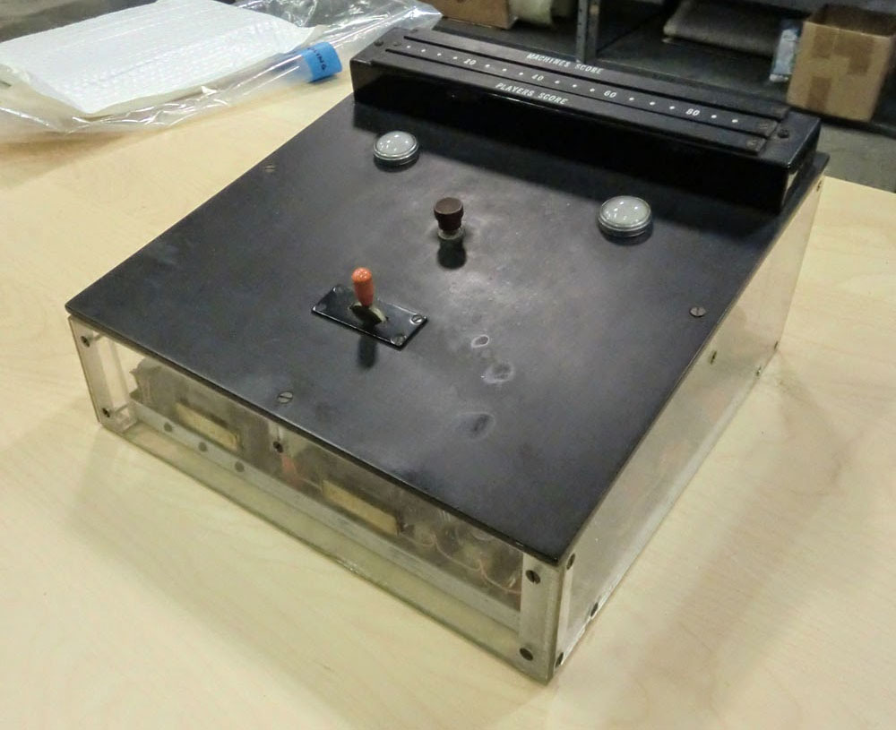

[Photo: Poundstone (2014)](http://william-poundstone.com/blog/2015/7/30/how-i-beat-the-mind-reading-machine)

## Hedge

- Binary case can be generalized to experts making any kind of prediction, with arbitrary non-negative loss function
  - Any output: discrete, scalar, vector, etc, all permitted
  - Sufficient that $\ell^2(.,.)\leq B$: bounded loss, eg due to bounded outcomes
- **Hedge** algorithm takes in $n$ experts, with initial weights $w_{i,0}=1$
- Predict $y_{t+1}$ using expert $i$ forecast $\widehat{y}_{i,t+1}$ with probability $p_{i,t}=\frac{w_{i,t}}{\sum_{i=1}^nw_{i,t}}$
- Observe losses $\ell_{i,t}=\ell(y_{t+1},\widehat{y}_{i,t+1})$ for each expert
- Update weights to $w_{i,t+1}=w_{i,t}\exp(-\epsilon\ell_{i,t})$ and repeat for next forecast
- Analysis shows expected regret bounded by $\epsilon\sum_{t=1}^{T}\sum_{i=1}^{n}p_{i,t}\ell^2_{i,t} +\frac{\log n}{\epsilon}$
- Choosing $\epsilon=\sqrt{\frac{\log n}{BT}}$, upper bound is $2\sqrt{B T\log n}$
- Regret grows sublinearly in $T$, depends weakly on number of experts

## Hedge: Applications

- Hedge provides alternative approach to model selection
- Can use for hyperparameter choice like AIC/BIC/Cross-validation etc
- Allows combining input of large set of models of diverse types
  - Choice depends on past performance only, not model structure
  - Inputs can be simple or complicated, or even based on human judgment
  - Can’t use AIC to compare VAR, random forest, and a CNBC pundit
- Does not require stationarity or correct specification or existence of a probability distribution over outcomes
  - Does require boundedness: useful for outcomes with known range
- Guarantees performance near best in class on realized outcomes
  - Contrast oracle guarantees: performance near best in class for **risk**
- Rapidly (exponentially fast) downweights bad models, maintains weights on those with good performance
- Essentially random near start of run: good performance coming from middle-to-end
  - This is typical feature of online algorithms
  - Choice of update speed $\epsilon$ depends on horizon $T$

## General Purpose Methods: Online Convex Optimization

- Can we move beyond case of finite comparison class of “experts” to methods that apply to more general variable structures and comparison classes?
- One large class of problems where this is feasible are **online convex optimization** problems
- If realized loss functions $\ell(y_{t+1},.)$ are **convex** in $f_t(.)$, there are general purpose methods with strong regret guarantees
- Convexity means $\ell(y_{t+1},ax+(1-a)z)\leq a\ell(y_{t+1},x)+(1-a)\ell(y_{t+1},z)$ for any $a\in[0,1]$
  - Bowl shaped functions
  - Contains quadratic loss, absolute value loss, linear loss, etc
  - Does not contain discrete case: randomization needed to make loss linear
- Hedge and online regression with convex $\ell$ are special cases of this setup
- Next class: general algorithms and conditions
  - Preview: Look a lot like (regularized) ERM

## Conclusions

- Online learning methods provide principled way to evaluate and implement stream of iteratively updated predictions
- Regret based analyses ensure robustness against arbitrary sequences, relative to a set of comparison models
  - An algorithm that produces low total expected regret over time can be trusted to have adequate performance regardless of what kind of new data comes in
- For finite model sets, a useful class of procedures puts weights on the models based on past performance, then chooses randomly based on weights
  - Hedge algorithm takes many models or experts as inputs, outputs low expected regret sequence of predictions
  - Randomization critical, as without it worst case regret is linear in $T$

## References

- Elad Hazan *Introduction to Online Convex Optimization* Foundations and Trends in Optimization, vol. 2, no. 3-4 (2015) 157–325.
  - Textbook on online learning, from an optimization theory perspective
- John Maynard Keynes *The General Theory of Employment, Interest, and Money* (1936)
  - Aside from introducing whole framework of 20th century macroeconomics, insightful chapters on investor psychology
- Shai Shalev-Shwartz *Online Learning and Online Convex Optimization* Foundations and Trends in Machine Learning Vol. 4, No. 2 (2011) 107–194
  - Shorter intro to online learning